# Zambia Corridor City Scan

## Urban Flooding

### Fluvial

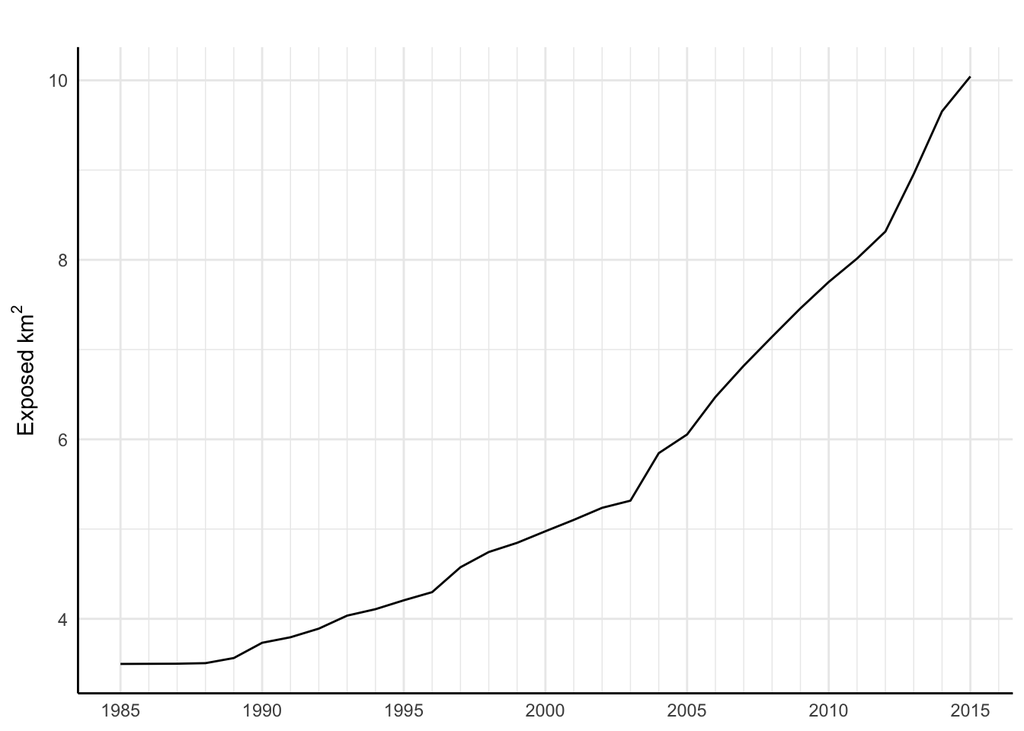

| year | cumulative_sq_km | exposed_km2 | percent_exposed |
| --- | --- | --- | --- |
| 1985 | 273.148 | 3.497568 | 1.28% |
| 2015 | 553.107 | 10.042942 | 1.82% |

In **1985**, **3.5** km² of the built-up area (**1.28%**) was exposed to river flooding at a minimum depth of 15 cm  
In **2015**, **10.04** km² of the built-up area (**1.82%**) was exposed

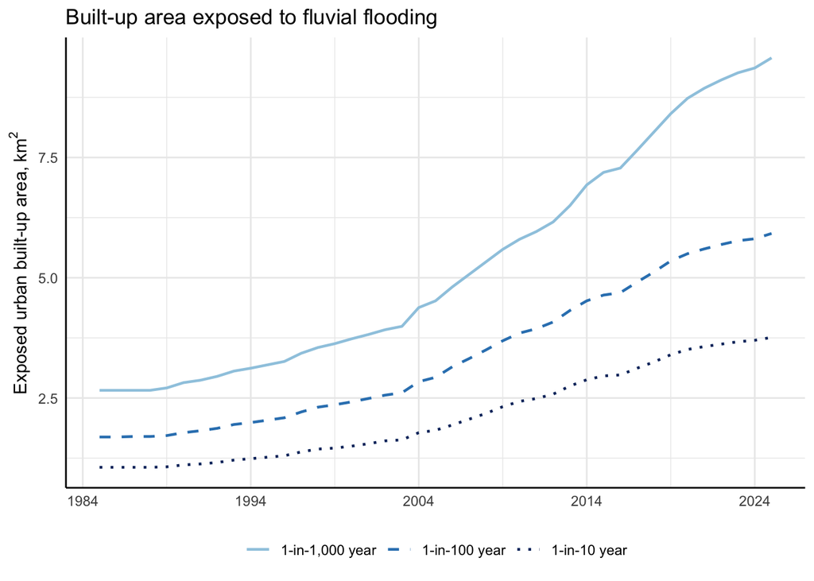

Fluvial **1-in-1,000 year** return period: **9.57** km² exposed by 2025  
Fluvial **1-in-100 year** return period: **5.92** km² exposed by 2025  
Fluvial **1-in-10 year** return period: **3.76** km² exposed by 2025

#### River — Flood + WSF Stats

| Year | uba_km2 | uba_km2_exposed | percent_uba_exposed |
| --- | --- | --- | --- |
| 1985 | 270.73 | 2.66 | 0.98% |
| 1986 | 270.73 | 2.66 | 0.98% |
| 1987 | 273.35 | 2.66 | 0.97% |
| 1988 | 274.03 | 2.66 | 0.97% |
| 1989 | 281.50 | 2.71 | 0.96% |
| 1990 | 292.13 | 2.82 | 0.97% |
| 1991 | 297.07 | 2.87 | 0.97% |
| 1992 | 301.90 | 2.95 | 0.98% |
| 1993 | 308.13 | 3.06 | 0.99% |
| 1994 | 313.69 | 3.12 | 1.00% |

[output cut: 31 more lines]

#### Population Exposure

| type | exposed_dense_pop_pct |
| --- | --- |
| fluvial_2020 | 1.443434 |

Percentage of population dense areas (>60th percentile density) in flood zone: **1.4%**

#### Roads in Flood Zone

| type | total_major_road_meter | meter_in_flood_zones | percentage_in_flood_zones |
| --- | --- | --- | --- |
| fluvial_2020 | 1599742 | 13795.33 | 0.8623473 |

#### Infrastructure in Flood Zone

| poi | total_pois | pois_in_flood_zone | percentage_in_flood_zone |
| --- | --- | --- | --- |
| schools | 521 | 5 | 0.9596929 |
| health | 219 | 3 | 1.3698630 |
| police | 21 | 0 | 0.0000000 |
| fire | 2 | 0 | 0.0000000 |

**0.9% of major roads**, **5 in 521 schools**, **3 in 219 health facilities**, **0 in 2 fire stations** and **0 in 21 police stations** are located in a **riverine** flood risk zone with a minimum depth of 15 cm

### Pluvial

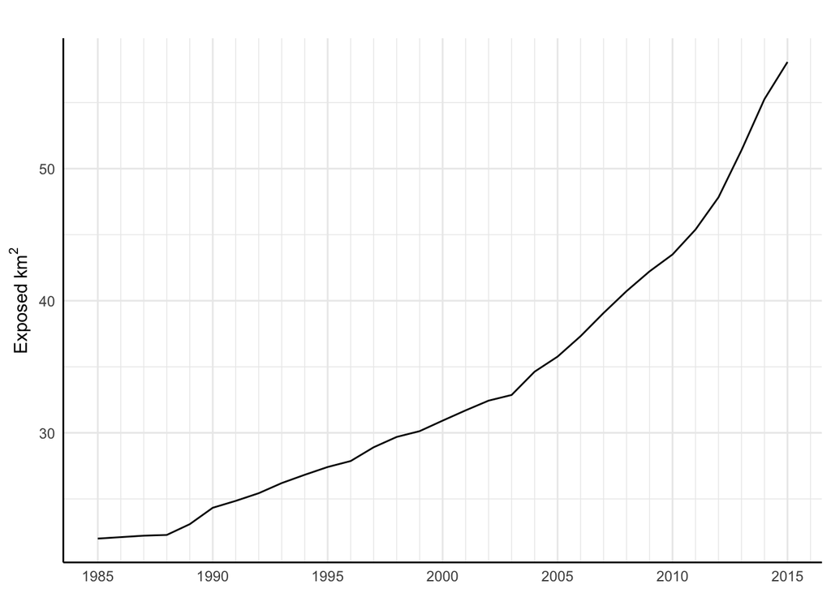

| year | cumulative_sq_km | exposed_km2 | percent_exposed |
| --- | --- | --- | --- |
| 1985 | 273.148 | 21.99499 | 8.05% |
| 2015 | 553.107 | 58.07211 | 10.50% |

In **1985**, **21.99** km² of the built-up area (**8.05%**) was exposed to rainwater flooding at a minimum depth of 15 cm  
In **2015**, **58.07** km² of the built-up area (**10.50%**) was exposed

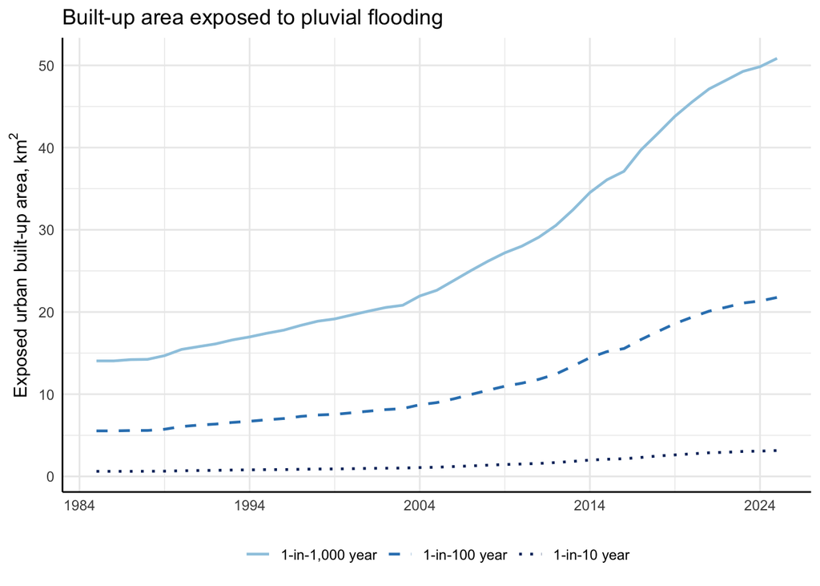

Pluvial **1-in-1,000 year** return period: **50.85** km² exposed by 2025  
Pluvial **1-in-100 year** return period: **21.77** km² exposed by 2025  
Pluvial **1-in-10 year** return period: **3.15** km² exposed by 2025

#### Rainwater — Flood + WSF Stats

| Year | uba_km2 | uba_km2_exposed | percent_uba_exposed |
| --- | --- | --- | --- |
| 1985 | 273.13 | 14.05 | 5.14% |
| 1986 | 273.13 | 14.05 | 5.14% |
| 1987 | 275.81 | 14.21 | 5.15% |
| 1988 | 276.47 | 14.24 | 5.15% |
| 1989 | 284.19 | 14.69 | 5.17% |
| 1990 | 294.97 | 15.45 | 5.24% |
| 1991 | 300.03 | 15.79 | 5.26% |
| 1992 | 304.93 | 16.12 | 5.29% |
| 1993 | 311.49 | 16.61 | 5.33% |
| 1994 | 317.40 | 16.97 | 5.35% |

[output cut: 31 more lines]

#### Population Exposure

| type | exposed_dense_pop_pct |
| --- | --- |
| pluvial_2020 | 9.82949 |

Percentage of population dense areas (>60th percentile density) in flood zone: **9.8%**

#### Roads in Flood Zone

| type | total_major_road_meter | meter_in_flood_zones | percentage_in_flood_zones |
| --- | --- | --- | --- |
| pluvial_2020 | 1635176 | 168412.8 | 10.29937 |

#### Infrastructure in Flood Zone

| poi | total_pois | pois_in_flood_zone | percentage_in_flood_zone |
| --- | --- | --- | --- |
| schools | 521 | 28 | 5.374280 |
| health | 219 | 11 | 5.022831 |
| police | 21 | 1 | 4.761905 |
| fire | 2 | 0 | 0.000000 |

**10.3% of major roads**, **28 in 521 schools**, **11 in 219 health facilities**, **0 in 2 fire stations** and **1 in 21 police stations** are located in a **surface water** flood risk zone with a minimum depth of 15 cm

### Coastal

**No Coastal flood data available**  
NULL NULL NULL NULL

### Combined Fluvial, Pluvial & Coastal

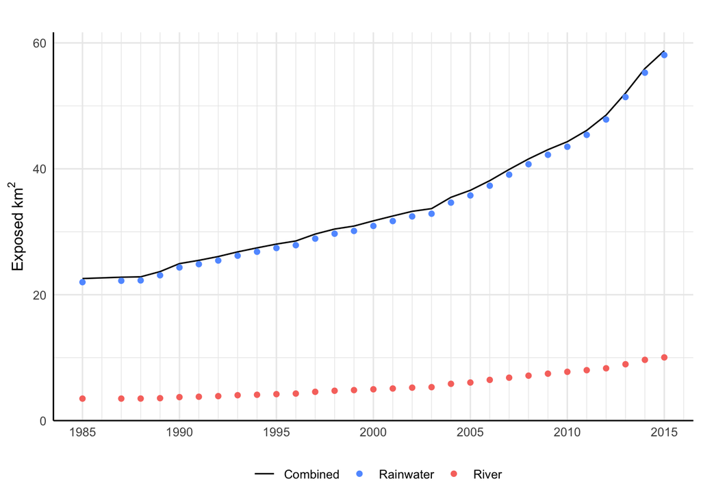

| year | cumulative_sq_km | exposed_km2 | percent_exposed |
| --- | --- | --- | --- |
| 1985 | 273.148 | 22.56607 | 8.26% |
| 2015 | 553.107 | 58.75238 | 10.62% |

In **1985**, **22.57** km² of the built-up area (**8.26%**) was exposed to riverine, surface water, or coastal flooding at a minimum depth of 15 cm  
In **2015**, **58.75** km² of the built-up area (**10.62%**) was exposed

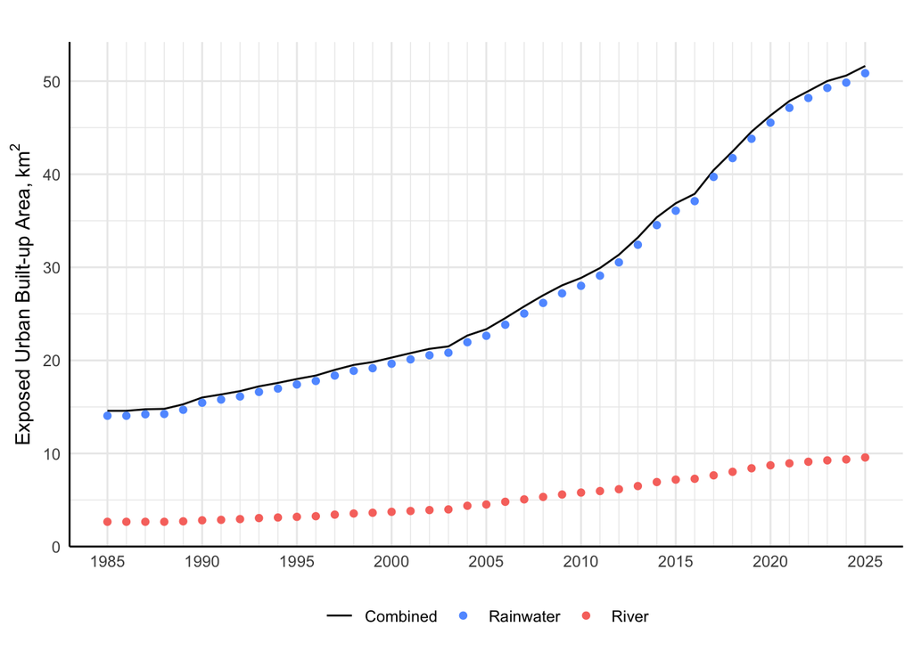

**River**: from **2.66** km² exposed in 1985 to **9.57** km² in 2025 (**1.33%** of built-up area)  
**Rainwater**: from **14.05** km² exposed in 1985 to **50.85** km² in 2025 (**6.91%** of built-up area)  
**Combined**: from **14.58** km² exposed in 1985 to **51.63** km² in 2025 (**7.20%** of built-up area)

#### Combined — Flood + WSF Stats

| Year | uba_km2 | uba_km2_exposed | percent_uba_exposed |
| --- | --- | --- | --- |
| 1985 | 270.73 | 14.58 | 5.39% |
| 1986 | 270.73 | 14.58 | 5.39% |
| 1987 | 273.35 | 14.75 | 5.39% |
| 1988 | 274.03 | 14.79 | 5.40% |
| 1989 | 281.50 | 15.28 | 5.43% |
| 1990 | 292.13 | 16.01 | 5.48% |
| 1991 | 297.07 | 16.34 | 5.50% |
| 1992 | 301.90 | 16.70 | 5.53% |
| 1993 | 308.13 | 17.21 | 5.59% |
| 1994 | 313.69 | 17.58 | 5.60% |

[output cut: 31 more lines]

#### Population Exposure

| type | exposed_dense_pop_pct |
| --- | --- |
| comb_2020 | 10.11298 |

Percentage of population dense areas (>60th percentile density) in flood zone: **10.1%**

#### Roads in Flood Zone

| type | total_major_road_meter | meter_in_flood_zones | percentage_in_flood_zones |
| --- | --- | --- | --- |
| comb_2020 | 1599742 | 166485.9 | 10.40705 |

#### Infrastructure in Flood Zone

| poi | total_pois | pois_in_flood_zone | percentage_in_flood_zone |
| --- | --- | --- | --- |
| schools | 521 | 28 | 5.374280 |
| health | 219 | 8 | 3.652968 |
| police | 21 | 1 | 4.761905 |
| fire | 2 | 0 | 0.000000 |

**10.4% of major roads**, **28 in 521 schools**, **8 in 219 health facilities**, **0 in 2 fire stations** and **1 in 21 police stations** are located in a **riverine**, **surface water**, **or coastal** flood risk zone with a minimum depth of 15 cm

## Sectoral GDP Flood Exposure

High GDP areas are defined as pixels above the 60th percentile of GDP values within the AOI.

### River Flooding

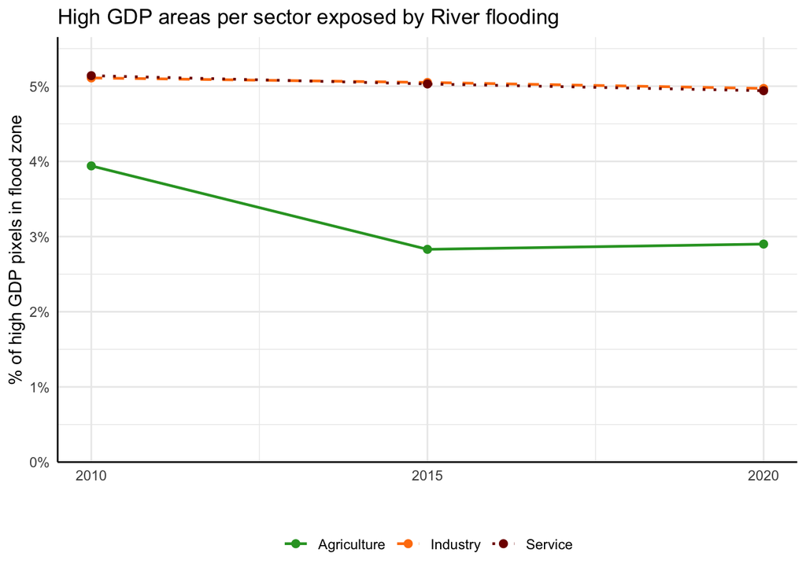

| year | sector | pct_high_gdp_in_flood | exposed_gdp_M | pct_gdp_exposed |
| --- | --- | --- | --- | --- |
| 2010 | Agriculture | 3.94 | 66447.66 | 4.48 |
| 2015 | Agriculture | 2.83 | 39407.44 | 3.83 |
| 2020 | Agriculture | 2.90 | 26876.28 | 3.12 |
| 2010 | Industry | 5.11 | 1010704.95 | 4.95 |
| 2015 | Industry | 5.05 | 942661.32 | 4.71 |
| 2020 | Industry | 4.97 | 880011.10 | 4.54 |
| 2010 | Service | 5.14 | 772141.94 | 6.39 |
| 2015 | Service | 5.03 | 1009595.48 | 6.34 |
| 2020 | Service | 4.94 | 984773.57 | 6.10 |

### Rainwater Flooding

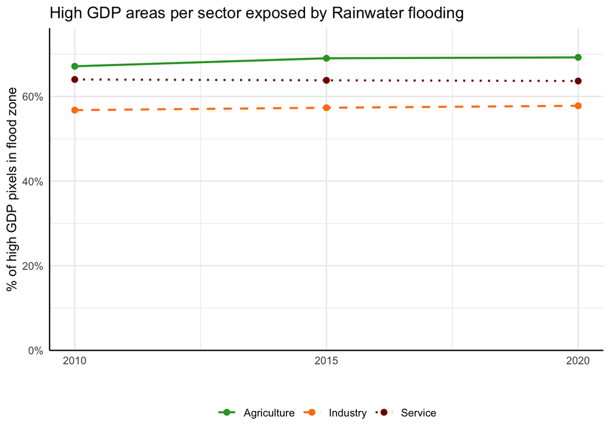

| year | sector | pct_high_gdp_in_flood | exposed_gdp_M | pct_gdp_exposed |
| --- | --- | --- | --- | --- |
| 2010 | Agriculture | 67.14 | 1093870.3 | 66.01 |
| 2015 | Agriculture | 69.03 | 760510.2 | 67.07 |
| 2020 | Agriculture | 69.24 | 624998.7 | 67.40 |
| 2010 | Industry | 56.78 | 12093608.3 | 59.14 |
| 2015 | Industry | 57.34 | 11910346.8 | 59.32 |
| 2020 | Industry | 57.80 | 11623424.5 | 59.70 |
| 2010 | Service | 64.02 | 6190103.0 | 50.12 |
| 2015 | Service | 63.82 | 8219094.8 | 50.47 |
| 2020 | Service | 63.66 | 8431397.6 | 51.00 |

### Coastal Flooding

**No coastal flood data available**

## Total Sectoral GDP Flood Exposure

Total sectoral GDP is the sum of agriculture, industry, and service GDP per pixel. High GDP areas below are defined using the 60th percentile of this total.

### River Flooding

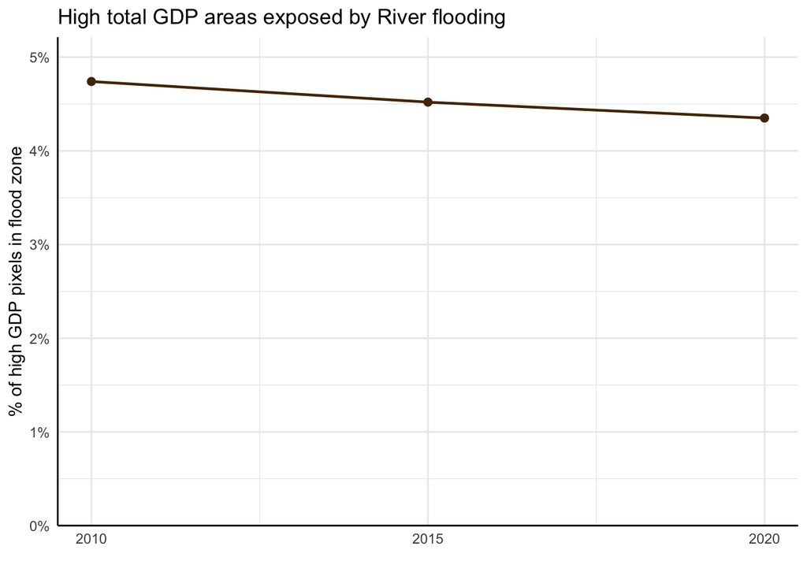

| year | pct_high_gdp_in_flood | exposed_gdp_M | pct_gdp_exposed |
| --- | --- | --- | --- |
| 2010 | 4.74 | 1833858 | 5.42 |
| 2015 | 4.52 | 1977889 | 5.37 |
| 2020 | 4.35 | 1878525 | 5.18 |

### Rainwater Flooding

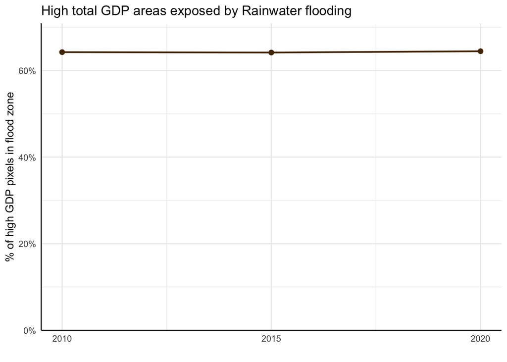

| year | pct_high_gdp_in_flood | exposed_gdp_M | pct_gdp_exposed |
| --- | --- | --- | --- |
| 2010 | 64.24 | 19361218 | 56.43 |
| 2015 | 64.15 | 20873486 | 55.86 |
| 2020 | 64.45 | 20670067 | 56.14 |

### Coastal Flooding

**No coastal flood data available**

## Flood Events

Tally of flood events

| count | DEAD | DISPLACED |
| --- | --- | --- |
| 6 | 30 | 308600 |

Median flood event

| DEAD | DISPLACED | duration |
| --- | --- | --- |
| 4 | 9000 | 44.5 |

Causes of flood events

| MAINCAUSE | n |
| --- | --- |
| Heavy rain | 5 |
| Monsoonal Rain | 1 |

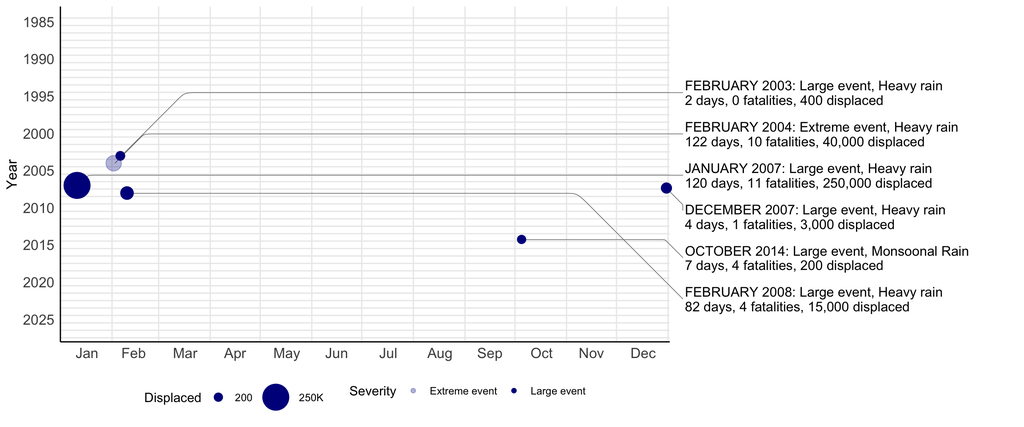

## Earthquakes

| text | location |
| --- | --- |
| MAY 1958; M5.75; 319 km away | 125 Km Wsw Of Nchelenge, Zambia |
| AUGUST 1959; M5.47; 281 km away | 63 Km W Of Mumbwa, Zambia |
| SEPTEMBER 1963; M5.3; 498 km away | 29 Km Wsw Of Siavonga, Zambia |
| JANUARY 1967; M5.6; 306 km away | 37 Km Nw Of Mwense, Zambia |
| MAY 1968; M5.6; 395 km away | 41 Km Wsw Of Namwala, Zambia |
| DECEMBER 1968; M5.7; 374 km away | 64 Km Ene Of Lukulu, Zambia |
| DECEMBER 1972; M5.6; 490 km away | 44 Km Ese Of Gwembe, Zambia |
| FEBRUARY 1973; M5; 490 km away | 40 Km Ese Of Gwembe, Zambia |
| MARCH 1973; M5.1; 481 km away | 42 Km E Of Gwembe, Zambia |
| APRIL 1973; M4.7; 479 km away | 46 Km E Of Gwembe, Zambia |

[output cut: 60 more lines]

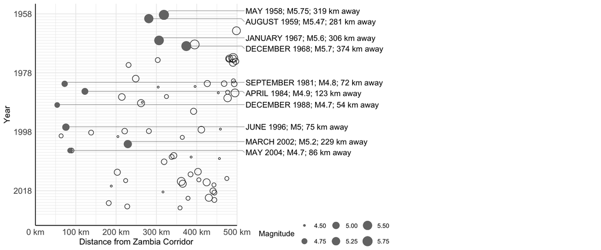

## Cyclones

**No cyclone data available**

## Photovoltaic Potential (PV)

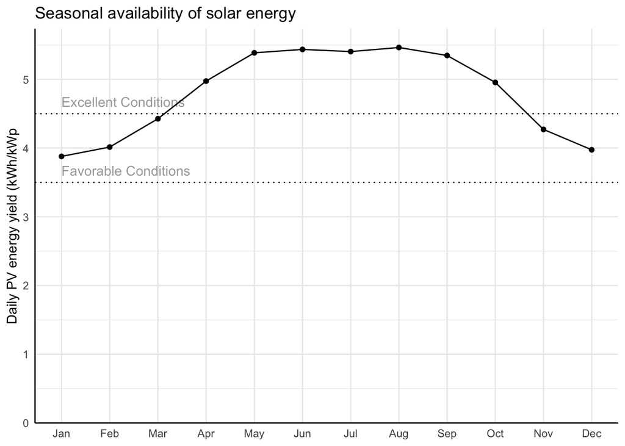

| month | max | min | mean |
| --- | --- | --- | --- |
| 1 | 4.03 | 3.66 | 3.878612 |
| 2 | 4.28 | 3.76 | 4.014270 |
| 3 | 4.65 | 4.15 | 4.426180 |
| 4 | 5.19 | 4.75 | 4.974162 |
| 5 | 5.58 | 5.20 | 5.385252 |
| 6 | 5.60 | 5.10 | 5.434681 |
| 7 | 5.57 | 5.11 | 5.403330 |
| 8 | 5.60 | 5.08 | 5.462649 |
| 9 | 5.63 | 4.78 | 5.346499 |
| 10 | 5.31 | 4.45 | 4.954444 |

[output cut: 2 more lines]

## FWI

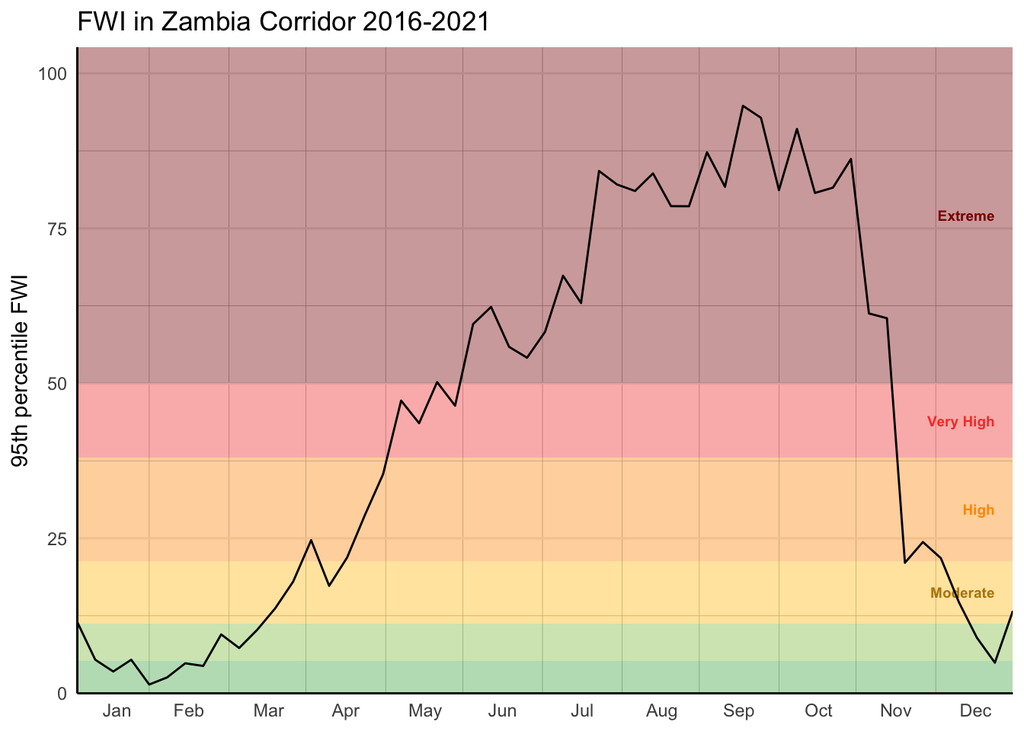